# Posthoc Testing in Two-Way Analyses

## Introduction

- Recall that ANOVA allows us to compare the means of three or more groups.
- In one-way ANOVA, we are only considering one factor (grouping variable).
- On Monday, we discussed two-way ANOVA, which allows us to consider a second factor (grouping variable).
- Today, we are discussing profile plots and posthoc tests in the two-way ANOVA setting.

## `R` Setup

```r
library(tidyverse)
library(ssstats)

supplement_heart_rate <- read_csv("https://raw.githubusercontent.com/samanthaseals/STA4173Fa26/refs/heads/main/lectures/data/supplement_heart_rate.csv")
exercise_recovery <- read_csv("https://raw.githubusercontent.com/samanthaseals/STA4173Fa26/refs/heads/main/lectures/data/exercise_recovery.csv")
```

## Two-Way ANOVA: Profile Plots

- We can construct profile plots to display treatment group means.
  - *y*-axis: always the average outcome
  - *x*-axis: either factor A or B
  - “lines” on the plot: the factor that was not selected for the *x*-axis
- Note that this is just a graph of the means!
  - It’s valid to construct a profile plot regardless of significance.

## Two-Way ANOVA: Profile Plots (R)

- We will use the `profile_plot()` function from `library(ssstats)` to construct basic profile plots.

```r
dataset_name |> profile_plot(continuous = continuous_variable,
                              xaxis = variable_on_x,
                              lines = variable_for_lines)
```

## Example 1

- Fluttershy asks: “Does the supplement affect every pony type in the same way?”
- We used the `supplement_heart_rate` dataset to determine if the effect of treatment on resting heart rate depends on pony type.

| pony_id | treatment | pony_type | resting_heart_rate_bpm |
| --- | --- | --- | --- |
| FS001 | Placebo | Earth pony | 63.7 |
| FS002 | Placebo | Earth pony | 64.1 |
| FS003 | Placebo | Earth pony | 67.5 |

## Example 1

- We want to work towards a profile plot. The first question we ask is what levels are in each variable?

```r
supplement_heart_rate |> count(pony_type)
```

| pony_type | n |
| --- | --- |
| Earth pony | 24 |
| Pegasus | 24 |
| Unicorn | 24 |

```r
supplement_heart_rate |> count(treatment)
```

| treatment | n |
| --- | --- |
| Placebo | 36 |
| Supplement | 36 |

## Example 1

- Neither variable has natural ordering.
  - Treatment: placebo, supplement
  - Pony type: earth, pegasus, unicorn
- My choice would be:
  - put pony type on the *x*-axis
  - create lines for treatment
- Why?
  - When there is no ordering, we then move to thinking about how many lines will be created.
  - It will be much easier to draw conclusions with fewer lines (graph is less busy).

## Example 1

- Constructing the profile plot,

```r
supplement_heart_rate |> profile_plot(outcome = resting_heart_rate_bpm,
                              xaxis = pony_type,
                              lines = treatment)
```

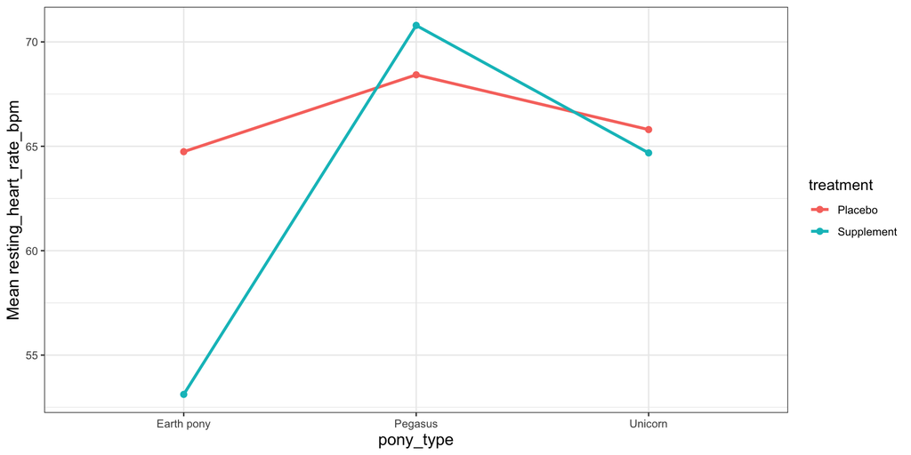

## Example 1

- What does it look like if we switch `xaxis` and `lines`?

```r
supplement_heart_rate |> profile_plot(outcome = resting_heart_rate_bpm,
                              xaxis = treatment,
                              lines = pony_type)
```

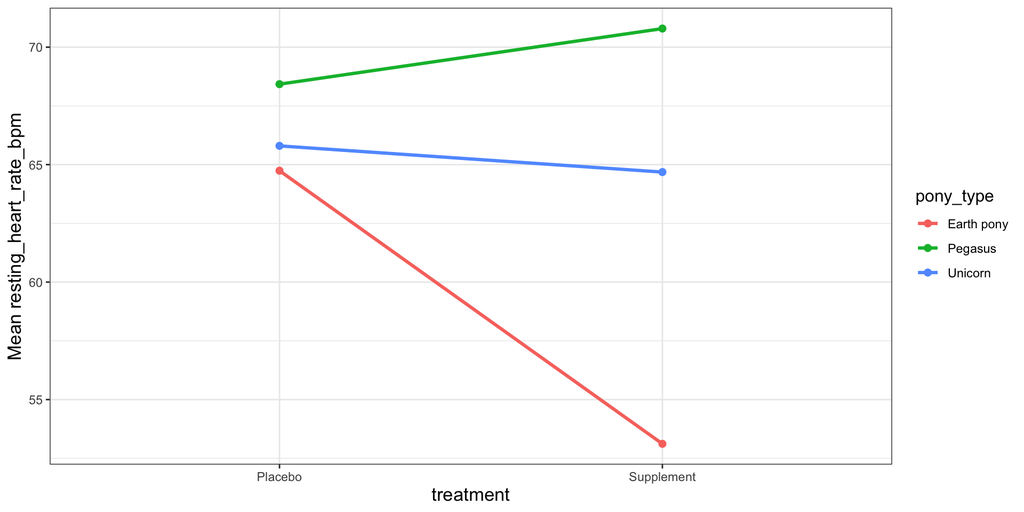

## Example 2

- Twilight Sparkle asks: “Can the Ponyville clinic help ponies recover faster after exercise? Does the treatment work the same way across pony types?”
- We used the `exercise_recovery` to test whether the effect of recovery treatment depends on pony type.

| pony_id | treatment | pony_type | recovery_time_min |
| --- | --- | --- | --- |
| TS001 | Standard care | Earth pony | 27.3 |
| TS002 | Standard care | Earth pony | 35.8 |
| TS003 | Standard care | Earth pony | 33.5 |

## Example 2

- What levels are in each variable?

```r
exercise_recovery |> count(treatment)
```

| treatment | n |
| --- | --- |
| Enhanced treatment | 36 |
| New treatment | 36 |
| Standard care | 36 |

```r
exercise_recovery |> count(pony_type)
```

| pony_type | n |
| --- | --- |
| Earth pony | 36 |
| Pegasus | 36 |
| Unicorn | 36 |

## Example 2

- Neither variable has natural ordering.
  - Treatment: enhanced, new, standard
  - Pony type: earth, pegasus, unicorn
- My choice would be:
  - put treatment on the *x*-axis
    - impose ordering: standard, new, enhanced
  - create lines for pony type

```r
exercise_recovery <- exercise_recovery |>
  mutate(treatment = factor(treatment,
                            levels = c("Standard care", "New treatment", "Enhanced treatment")))
```

## Example 2

- Constructing the profile plot,

```r
exercise_recovery |> profile_plot(outcome = recovery_time_min,
                              xaxis = treatment,
                              lines = pony_type)
```

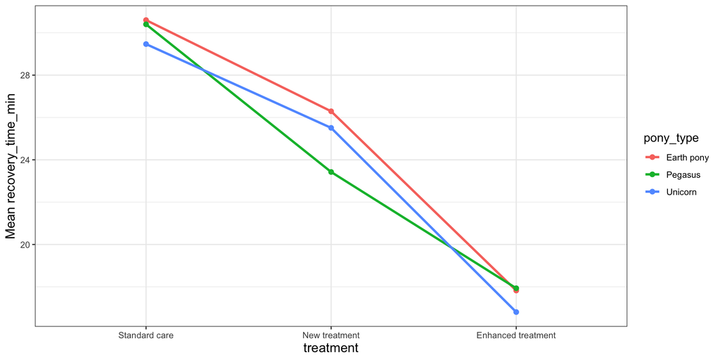

## Example 2

- What if we switch the *x*-axis and the lines?

```r
exercise_recovery |> profile_plot(outcome = recovery_time_min,
                              xaxis = pony_type,
                              lines = treatment)
```

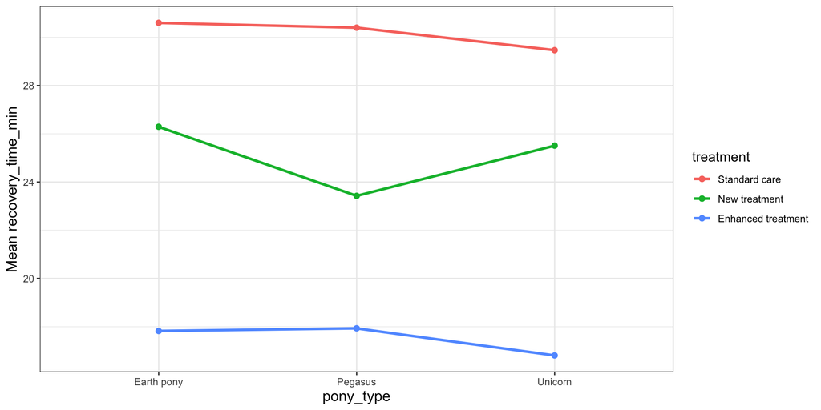

## Posthoc Testing

- Recall our hypotheses for main effects,
  - $H_0: \mu_1 = \mu_2 = ... = \mu_a$
  - $H_1:$ at least one $\mu_i$ is different
- We will again turn to posthoc tests to determine pairwise differences.
- Tying this to the profile plot, posthoc tests are giving us the $p$-values corresponding to pairwise differences.

## Posthoc Testing (`R`)

- We will again use the `posthoc()` function,

```r
dataset_name |> posthoc(outcome = response_variable,
                        A = factor_A,
                        B = factor_B,
                        interaction = TRUE or FALSE,
                        adjust = TRUE or FALSE)
```

## Example 1

- Fluttershy asks: “Does the supplement affect every pony type in the same way?”
- We used the `supplement_heart_rate` dataset to determine if the effect of treatment on resting heart rate depends on pony type.

```r
supplement_heart_rate |> anovas(outcome = resting_heart_rate_bpm,
                                A = pony_type,
                                B = treatment)
```

```
Two-way ANOVA (with interaction)

Source               df         SS        MS       F  p-value
────────────────────────────────────────────────────────
pony_type             2  1383.6803  691.8401  49.519  < 0.001
treatment             1   215.2813  215.2813  15.409  < 0.001
pony_type:treatment   2   636.6508  318.3254  22.785  < 0.001
Residuals            66   922.0942   13.9711
────────────────────────────────────────────────────────


Hypotheses (pony_type:treatment):
H₀: There is no interaction between pony_type and treatment
H₁: There is an interaction between pony_type and treatment
Test statistic: F(2, 66) = 22.785
p-value: < 0.001
Conclusion: Reject the null hypothesis (p = < 0.001 < α = 0.050)
```

## Example 1

- We can look at the posthoc test of the interaction term.
- Treating it as confirmatory,

```r
supplement_heart_rate |> posthoc(outcome = resting_heart_rate_bpm,
                                 A = pony_type,
                                 B = treatment,
                                 adjust = TRUE)
```

```
Post-hoc analysis: Tukey's HSD

Following: two-way ANOVA (resting_heart_rate_bpm ~ pony_type * treatment)

Main effect: pony_type
Comparison             Difference  p-value
─────────────────────────────────────────────
Pegasus vs Earth pony     10.6792  < 0.001  *
Unicorn vs Earth pony      6.3125  < 0.001  *
Unicorn vs Pegasus        -4.3667  < 0.001  *
─────────────────────────────────────────────

Main effect: treatment
Comparison             Difference  p-value
─────────────────────────────────────────────
Supplement vs Placebo     -3.4583  < 0.001  *
─────────────────────────────────────────────

Interaction: pony_type × treatment
Comparison                                   Difference  p-value
───────────────────────────────────────────────────────────────────
Pegasus:Placebo vs Earth pony:Placebo            3.6833    0.167
Unicorn:Placebo vs Earth pony:Placebo            1.0583    0.982
Earth pony:Supplement vs Earth pony:Placebo    -11.6250  < 0.001  *
Pegasus:Supplement vs Earth pony:Placebo         6.0500    0.002  *
Unicorn:Supplement vs Earth pony:Placebo        -0.0583    1.000
Unicorn:Placebo vs Pegasus:Placebo              -2.6250    0.524
Earth pony:Supplement vs Pegasus:Placebo       -15.3083  < 0.001  *
Pegasus:Supplement vs Pegasus:Placebo            2.3667    0.633
Unicorn:Supplement vs Pegasus:Placebo           -3.7417    0.154
Earth pony:Supplement vs Unicorn:Placebo       -12.6833  < 0.001  *
Pegasus:Supplement vs Unicorn:Placebo            4.9917    0.020  *
Unicorn:Supplement vs Unicorn:Placebo           -1.1167    0.977
Pegasus:Supplement vs Earth pony:Supplement     17.6750  < 0.001  *
Unicorn:Supplement vs Earth pony:Supplement     11.5667  < 0.001  *
Unicorn:Supplement vs Pegasus:Supplement        -6.1083    0.002  *
───────────────────────────────────────────────────────────────────

* p < α = 0.050
```

## Example 2

- Twilight Sparkle asks: “Can the Ponyville clinic help ponies recover faster after exercise? Does the treatment work the same way across pony types?”
- We used the `exercise_recovery` to test whether the effect of recovery treatment depends on pony type.

```r
exercise_recovery |> anovas(outcome = recovery_time_min,
                            A = pony_type,
                            B = treatment)
```

```
Two-way ANOVA (with interaction)

Source               df         SS         MS       F  p-value
─────────────────────────────────────────────────────────
pony_type             2    23.1424    11.5712   0.630    0.535
treatment             2  2909.4913  1454.7456  79.154  < 0.001
pony_type:treatment   4    47.5704    11.8926   0.647    0.630
Residuals            99  1819.4858    18.3786
─────────────────────────────────────────────────────────


Hypotheses (pony_type:treatment):
H₀: There is no interaction between pony_type and treatment
H₁: There is an interaction between pony_type and treatment
Test statistic: F(4, 99) = 0.647
p-value: 0.630
Conclusion: Fail to reject the null hypothesis (p = 0.630 ≥ α = 0.050)
```

## Example 2

- Twilight Sparkle asks: “Can the Ponyville clinic help ponies recover faster after exercise? Does the treatment work the same way across pony types?”
- We then removed the (non-significant) interaction term,

```r
exercise_recovery |> anovas(outcome = recovery_time_min,
                            A = pony_type,
                            B = treatment,
                            interaction = FALSE)
```

```
Two-way ANOVA (no interaction)

Source      df         SS         MS       F  p-value
────────────────────────────────────────────────
pony_type    2    23.1424    11.5712   0.638    0.530
treatment    2  2909.4913  1454.7456  80.254  < 0.001
Residuals  103  1867.0562    18.1268
────────────────────────────────────────────────


Hypotheses (pony_type):
H₀: All means across levels of pony_type are equal
H₁: At least one mean across levels of pony_type differs
Test statistic: F(2, 103) = 0.638
p-value: 0.530
Conclusion: Fail to reject the null hypothesis (p = 0.530 ≥ α = 0.050)

Hypotheses (treatment):
H₀: All means across levels of treatment are equal
H₁: At least one mean across levels of treatment differs
Test statistic: F(2, 103) = 80.254
p-value: < 0.001
Conclusion: Reject the null hypothesis (p = < 0.001 < α = 0.050)
```

## Example 2

- We now look at the posthoc test for *only* `treatment`
  - We did not detect a difference between the pony types ($p = 0.530$).
- Treating it as exploratory,

```r
exercise_recovery |> posthoc(outcome = recovery_time_min,
                             A = pony_type,
                             B = treatment,
                             interaction = FALSE,
                             adjust = FALSE)
```

```
Post-hoc analysis: Fisher's LSD

Following: two-way ANOVA (recovery_time_min ~ pony_type + treatment)

Main effect: pony_type
Comparison             Difference  p-value
─────────────────────────────────────────────
Pegasus vs Earth pony     -0.9861    0.328
Unicorn vs Earth pony     -0.9778    0.332
Unicorn vs Pegasus         0.0083    0.993
─────────────────────────────────────────────

Main effect: treatment
Comparison                           Difference  p-value
───────────────────────────────────────────────────────────
New treatment vs Standard care          -5.0806  < 0.001  *
Enhanced treatment vs Standard care    -12.6333  < 0.001  *
Enhanced treatment vs New treatment     -7.5528  < 0.001  *
───────────────────────────────────────────────────────────

* p < α = 0.050
```

## Wrap Up

- In this lecture, we have covered posthoc testing and profile plots in two-way ANOVA.
  - Interactions.
  - Main effects.
- We can tie the results from posthoc testing to the profile plot.
  - The profile plot is allowing us to visualize the differences between factors or treatment groups.
- Next week:
  - Monday: `R` workshop - bring laptop!
  - Wednesday: Test 2 - ANOVA